# FintelSpotlight: Value and Momentum Everywhere

Fintelligence Academy

2023-06-16

[figure not shown]

# 1 Introduction

The paper *[Value and Momentum Everywhere](https://papers.ssrn.com/sol3/papers.cfm?abstract_id=2174501)* conducted across eight disparate markets and asset classes reveals a consistent value and momentum return premium and a strong common factor structure. This study brings fresh perspectives to two widely studied capital market phenomena, the “value” effect and the “momentum” effect, and their relationship with an asset’s returns.

The “value” effect refers to the ratio of an asset’s long-term value to its current market value, while the “momentum” effect denotes the correlation between an asset’s return and its recent performance history. These factors have garnered significant attention in asset pricing studies and debates on market efficiency. The research uncovers significant return premiums for both value and momentum across all asset classes, presenting a challenge to prevailing theories that predominantly focus on U.S. equities.

A striking finding is the positive correlation between similar strategies across different markets, regardless of asset classes. However, value and momentum are negatively correlated with each other both within and across asset classes, indicating the presence of common global risks related to both. This led researchers to propose a three-factor model, consisting of a global market index, a zero-cost value strategy applied across all asset classes, and a zero-cost momentum strategy across all assets. The model effectively captures the comovement and cross-section of average returns globally across asset classes and within an asset class.

The common global factor structure’s source remains partially elusive, with only modest links to macroeconomic variables such as business cycles, consumption, and default risk. However, significant evidence suggests liquidity risk plays a crucial role, negatively relating to value and positively to momentum across all asset classes. This correlation is particularly driven by funding risk, which gained prominence after the funding crisis of 1998. Despite this, liquidity risk only explains a small fraction of value and momentum return premiums and comovement.

# 2 Dataset: Asset Class

This research aims to construct value and momentum portfolios across various markets and asset classes. The asset classes in focus are global individual stocks, global equity indices, currencies, global government bonds, and commodity futures.

- Global Individual Stocks: The study uses a sample of individual stocks globally from four equity markets: the U.S., U.K., continental Europe, and Japan. The U.S. stocks come from the CRSP database and Compustat and are all common equities with at least 12 months of past return history from January 1972 to July 2011. The research excludes certain categories such as ADRs, REITs, financials, closed-end funds, foreign shares, and stocks priced under $1. Only the top 90% of total market capitalization is considered. Stocks from outside the U.S. are sourced from Datastream and Worldscope, applying the same selection criteria.
- Global Equity Indices: The universe of country equity index futures encompasses 18 developed equity markets ranging from Australia to the United States. Data on returns, prices, and book values are obtained from MSCI and Bloomberg for the period of January 1978 to July 2011.
- Currencies: Data on ten major global currencies, including Australia, Canada, Germany (spliced with the Euro), Japan, New Zealand, Norway, Sweden, Switzerland, the U.K., and the U.S., are obtained from Datastream, covering the period January 1979 to July 2011. Currency returns are computed using currency forward contracts or MSCI spot price data and Libor rates, all dollar-denominated.
- Global Government Bonds: Data on bond index returns are acquired from Bloomberg and Morgan Markets. The dataset includes short rates and 10-year government bond yields from Bloomberg, and inflation forecasts based on investment bank analysts’ estimates compiled by Consensus Economics. The study uses government bond data from ten countries covering the period from January 1982 to July 2011.
- Commodity Futures: This section of the research covers 27 different commodity futures obtained from several sources, including the London Metal Exchange, Intercontinental Exchange, Chicago Mercantile Exchange, Chicago Board of Trade, New York Mercantile Exchange, New York Commodities Exchange, New York Board of Trade, and Tokyo Commodity Exchange. The data covers the period from January 1972 to July 2011. Commodity futures returns are computed using a similar method to that of Bessembinder (1992), de Roon, Nijman, and Veld (2000), Moskowitz, Ooi, and Pedersen (2012), and Koijen et al. (2012).

  > Each day compute the daily excess return of the most liquid futures contract, which is typically the nearest- or next nearest-to-delivery contract, and then compound the daily returns to a total return index from which we compute returns at a monthly horizon. All returns are denominated in U.S. dollars and do not include the return on collateral associated with the futures contract.

# 3 Methodology: Measure of Value and Momentum Factor

In order to measure value and momentum across diverse asset classes, the study employs simple and standard measures that focus on avoiding data snooping while ensuring consistency. While these methods might not predict returns in each class optimally, they maintain a uniform approach beneficial for comparative studies.

**Value** - to measure the value in individual stocks, the study uses the **book-to-market ratio (BE/ME)** – the ratio of the book value of equity to market value of equity. Book values are lagged six months to ensure data availability, while the most recent market values are used to compute the ratios. Using more recent prices in the value measure results in a more negative correlation between value and momentum and a slightly reduced value premium, however, it does not materially impact the study’s conclusions.

**Momentum** - the study adopts a common measure - the past 12-month cumulative raw return on the asset, skipping the most recent month’s return (MOM2–12). This method avoids the 1-month reversal in stock returns which might be related to liquidity or microstructure issues.

For other asset classes, similar value and momentum measures are defined where possible. Momentum is measured in the same way across all asset classes: **the return over the past 12 months, excluding the most recent month**. This method is applied uniformly, even though some asset classes like equity index futures and currencies suffer less from liquidity issues and might display stronger momentum returns without excluding the most recent month.

Attaining uniformity in value measures across different asset classes presents a challenge due to the absence of a book value measure for some assets. Therefore, the study uses simple, consistent measures of value for these assets. For instance, for country indices, the previous month’s BE/ME ratio for the MSCI index of the country is used. For commodities, value is defined as the logarithm of the spot price five years ago, divided by the most recent spot price. Similar measures are employed for currencies and bonds, using either the negative of the 5-year return on the exchange rate or the 5-year change in yields of 10-year bonds.

# 4 Conclusion

The research presents a comprehensive overview of return premiums to value and momentum strategies across global asset classes, revealing a strong common factor structure among their returns. While exposure to funding liquidity risk offers a partial explanation for this correlation, a more comprehensive framework is needed to account for the findings. The research thus provides a simple global three-factor model that could be useful for future research on pricing global assets across markets.

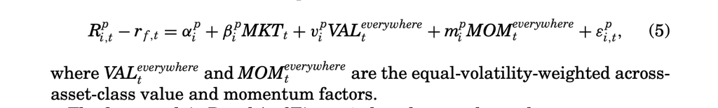

# 5 Reference

- Asness, C.S., Moskowitz, T.J. and Pedersen, L.H., 2013. Value and Momentum Everywhere. The Journal of Finance, 68(3), pp.929-985.